# **Explaining Portuguese exam results using SHAP**

The goal of this homework was to explain the results of students from their lifestyles and life situations. Using the conclusions from the previous homework, I use the Portuguese dataset only, since stronger relations were visible in it and there is also more data available. I found that the values given by shap match my intuition about the variables better than what I was able to find in the last homework by only looking at the plots. The model that is being explained is mostly XGBoost with the exception of the last subtask, where XGBoost is compared with a Random Forest model.

### **Subtask 4**

I found the requested observations. The first plot is from dalex:

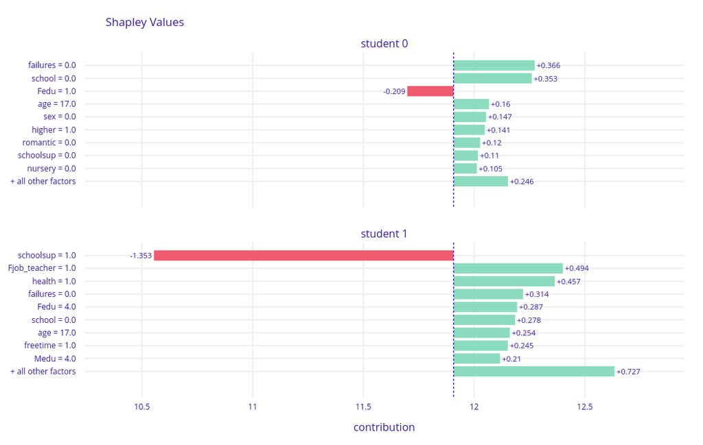

We can see, as was also visible in the last homework, that student receiving extra educational support is quite strongly correlated with the student having worse results. It is visible here - the first student doesn't receive educational support and this variable is much less important in their case. There are much more students that don't receive the support than those who do, and among those that don't there is much bigger variety in exam results than among those that do. Number of previous failures showed the greatest correlation with the result among the non-categorical variables and the two schools present in the dataset had significantly different scores. The fact that in the second case the father being a teacher is so important also makes sense - probably it's quite rare for a child whose father is a teacher to perform poorly.

And now the shap results:

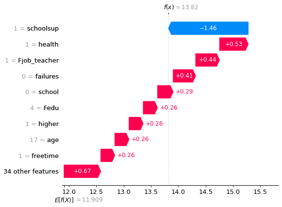

It looks similar to the previous case, but this time health is more important than father being a teacher in the second case.

### **Subtask 5**

The variable for which I was able to find that it had different attributions for different observations is the age of a student equal to 19. The results for dalex first again:

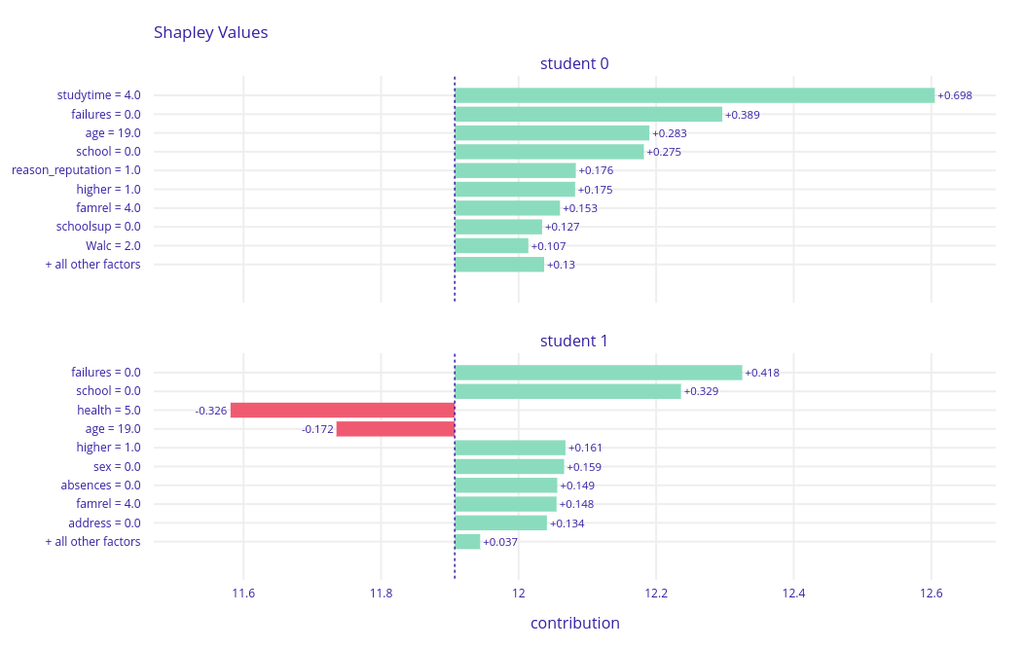

Now shap:

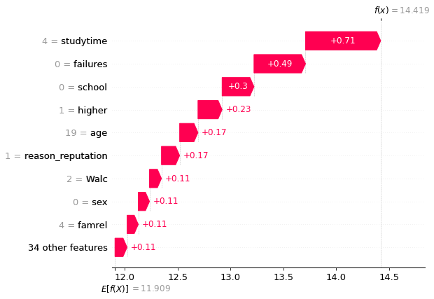

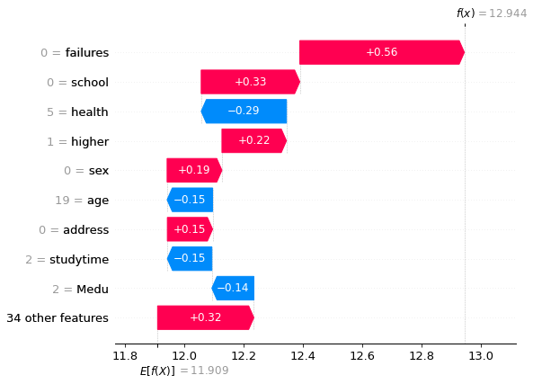

Some reason for this difference in the two samples could be the fact, that older students have more difficult topics, so if they don't study a lot, then when they get older their results decrease. But that is only one viable reason, there could most likely be many others.

### **Subtask 6**

In general the results are a bit different, but I wasn't able to observe anything drastic. It's mostly that sometimes one feature is a bit more important in one than in the other. Let's look at the specific example of the two random samples from subtask three.

Dalex results:

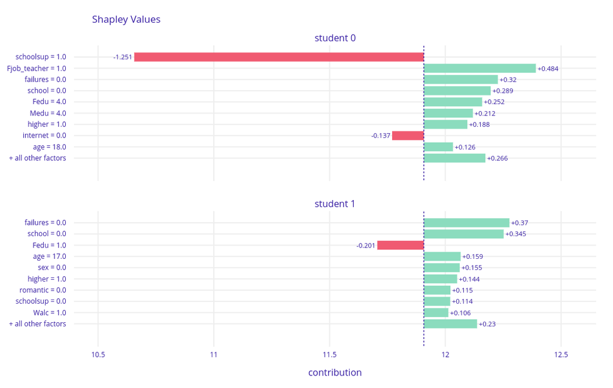

And shap:

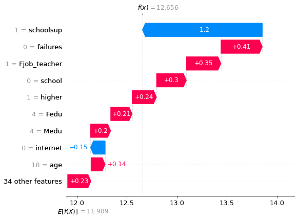

We can observe that they look pretty similar. One interesting hypothesis may be that shap from shap module attributes more importance to studytime=2 (which also showed up in the example in the previous exercise).

### **Subtask 7**

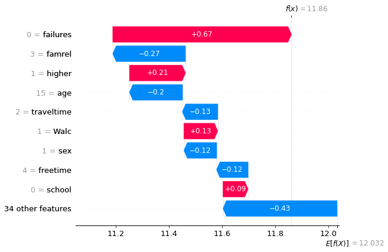

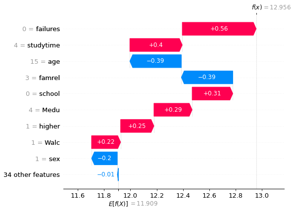

## **Appendix**

Contains the Python code used to create the above raport

# **Dataset**

This dataset contains the data about the scores of students of two different school in Portugal in math and Portuguese. The goal is to predict the final score of a student, using information about their lifestyle and background. I am going to focus only on predicting G3 - according to the description of the problem G1 and G2 are highly correlated with G3.

### **Imports**

We need to install the necessary modules.

```python
!pip install dalex
!pip install shap
```

And now import everything that is necessary.

```python
import pandas as pd
import matplotlib.pyplot as plt
import seaborn as sns
import numpy as np
import dalex as dx
import shap

from sklearn.model_selection import train_test_split
from sklearn.preprocessing import StandardScaler
from sklearn.ensemble import RandomForestRegressor
from xgboost import XGBRegressor
from sklearn.metrics import mean_squared_error
from sklearn.feature_selection import RFECV
```

Set the seeds for reproducibility.

```python
np.random.seed(10)
```

### **Data preparation**

We will start by reading the data.

```python
portuguese_df = pd.read_csv('Portuguese.csv')
```

Split into features and targets. The same as in the previous homework, we focus on predicting the final result only.

```python
port_x = portuguese_df.drop(['G3', 'G2', 'G1'], axis = 1)
port_y = portuguese_df[['G3']]
```

Categorical variables need to be encoded.

```python
def encode_categorical(df):
    df = df.copy()

    df = df.replace({'GP': 0, 'MS': 1})
    df = df.replace({'F': 0, 'M': 1})
    df = df.replace({'U': 0, 'R': 1})
    df = df.replace({'LE3': 0, 'GT3': 1})
    df = df.replace({'A': 0, 'T': 1})
    df = df.replace({'no': 0, 'yes': 1})

    onehot_features = ['Mjob', 'Fjob', 'reason', 'guardian']
    df = pd.concat([df, pd.get_dummies(df[onehot_features])], axis=1)
    df = df.drop(onehot_features, axis=1)

    return df
```

```python
port_x = encode_categorical(port_x)
```

## **Homework implementation**

Below the code used for solving each of the required homework tasks is contained. Only XGBoost is used with the exception of the subtask 7.

### **Subtask 1**

We train two models XGBoost and random forest model. We train on the whole dataset, since there isn't much data and it shouldn't matter for the explanations.

```python
models = {
    'Boosting': XGBRegressor(objective='reg:squarederror'),
    'Forest': RandomForestRegressor()
  }

for name, model in models.items():
    model.fit(port_x, port_y.values.ravel())
```

### **Subtask 2**

We sample two random observations from the dataset and calculate the predictions.

```python
samples = port_x.sample(2)

models["Boosting"].predict(samples)
```

[output not shown]

### **Subtask 3**

Now we use dalex and shap to calculate the variable attributions.

```python
dx_explainer = dx.Explainer(models["Boosting"], port_x, port_y, predict_function=lambda m, x: m.predict(x), label="XGBoost")
sh_explainer = shap.explainers.Tree(models["Boosting"], data=port_x, model_output="raw")
```

```
Preparation of a new explainer is initiated

  -> data              : 649 rows 43 cols
  -> target variable   : Parameter 'y' was a pandas.DataFrame. Converted to a numpy.ndarray.
  -> target variable   : 649 values
  -> model_class       : xgboost.sklearn.XGBRegressor (default)
  -> label             : XGBoost
  -> predict function  : <function <lambda> at 0x7fa101971560> will be used
  -> predict function  : Accepts only pandas.DataFrame, numpy.ndarray causes problems.
  -> predicted values  : min = 1.92, mean = 11.9, max = 16.6
  -> model type        : regression will be used (default)
  -> residual function : difference between y and yhat (default)
  -> residuals         : min = -8.78, mean = -0.00108, max = 5.47
  -> model_info        : package xgboost

A new explainer has been created!
```

First dalex:

```python
dx_shap_attributions = [dx_explainer.predict_parts(samples.iloc[[i]], type="shap", label=f'student {i}') for i in range(2)]
dx_shap_attributions[0].plot(dx_shap_attributions[1::])
```

[interactive chart not shown]

And now shap:

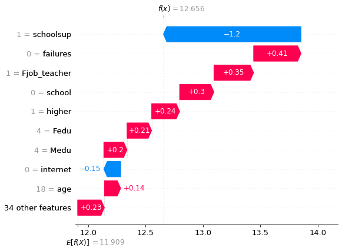

```python
shap_values = sh_explainer(samples)

for i in range(2):
    shap.plots.waterfall(shap_values[i])
```

### **Subtask 4**

I found two observations with the different variables of highest importance in the both considered packages.

```python
samples = port_x.iloc[[1, 7]]
dx_shap_attributions = [dx_explainer.predict_parts(samples.iloc[[i]], type="shap", label=f'student {i}') for i in range(2)]
dx_shap_attributions[0].plot(dx_shap_attributions[1::])
```

[interactive chart not shown]

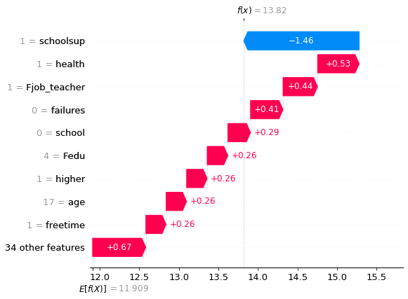

```python
samples = port_x.iloc[[1, 7]]
shap_values = sh_explainer(samples)
for i in range(2):
    shap.plots.waterfall(shap_values[i])
```

### **Subtask 5**

Age of 19 is old for a student. Sometimes it gives a positive attribution and sometimes a negative one.

```python
samples = port_x.iloc[[224, 290]]
dx_shap_attributions = [dx_explainer.predict_parts(samples.iloc[[i]], type="shap", label=f'student {i}') for i in range(2)]
dx_shap_attributions[0].plot(dx_shap_attributions[1::])
```

[interactive chart not shown]

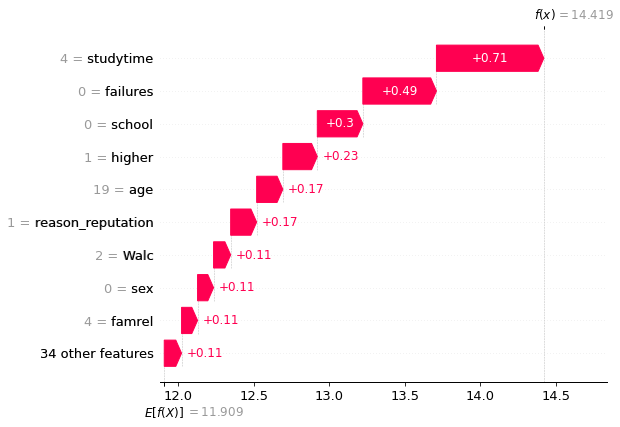

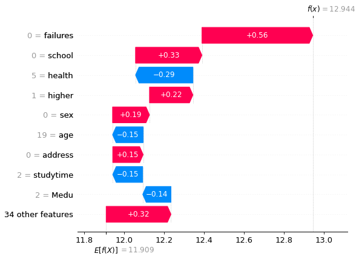

```python
shap_values = sh_explainer(samples)
for i in range(len(shap_values)):
    shap.plots.waterfall(shap_values[i])
```

### **Subtask 7**

Now we use the random forest model. I found this value by searching for two observations for which shap values differed the most.

```python
sh_explainer_forest = shap.explainers.Tree(models["Forest"], data=port_x, model_output="raw")
```

```python
samples = port_x[:100]
shap_values_forest = sh_explainer_forest(samples)
shap_values = sh_explainer(samples)
```

Found the sample where the MSE is greatest between the shap values of two models.

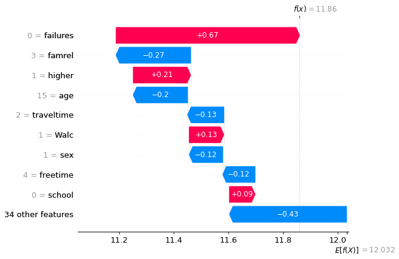

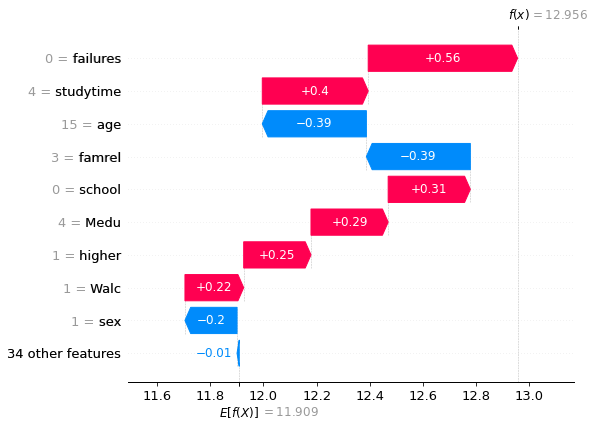

```python
shap.plots.waterfall(shap_values_forest[76])
shap.plots.waterfall(shap_values[76])
```